# Most Watched Movies and TV Shows Personal Project

Kira Novitchkova-Burbank

```r
#this R markdown file has a theme that requires prettydoc to be installed
library(prettydoc)
```

### Why I’m doing this project.

The reason why I’m doing this project is because I like watching movies and tv shows. Also, I thought it would be fun to visualize this same data in both R and Power BI.

I got this data from kaggle: https://www.kaggle.com/datasets/shiivvvaam/most-watched-movies-and-tv-shows

First, I do the initial setup and read in the data.

```r
#setup and reading in the data
setwd("C:\\Users\\vicno\\OneDrive\\Documents\\R")

library(readxl)
not_df_data <- read_excel('flixpatrol.xlsx') #changed this from csv to .xlsx file because R and I were having a problem accessing the file

#putting data in a data frame and making sure it loads
data_na <- data.frame(not_df_data)
head(data_na)
```

```
##   Rank                               Title    Type Premiere    Genre Watchtime
## 1    1                     The Night Agent TV Show     2023   Action 812100000
## 2    2                     Ginny & Georgia TV Show     2021    Drama 665100000
## 3    3                           The Glory TV Show     2022 Thriller 622800000
## 4    4                           Wednesday TV Show     2022  Fantasy 507700000
## 5    5 Queen Charlotte: A Bridgerton Story TV Show     2023    Drama 503000000
## 6    6                                 You TV Show     2018    Crime 440600000
##   Watchtime.in.Million
## 1               812.1M
## 2               665.1M
## 3               622.8M
## 4               507.7M
## 5               503.0M
## 6               440.6M
```

Removing missing values.

```r
#Remove missing values
data <- na.omit(data_na)
head(data, n=20)
```

```
##    Rank                               Title    Type Premiere        Genre
## 1     1                     The Night Agent TV Show     2023       Action
## 2     2                     Ginny & Georgia TV Show     2021        Drama
## 3     3                           The Glory TV Show     2022     Thriller
## 4     4                           Wednesday TV Show     2022      Fantasy
## 5     5 Queen Charlotte: A Bridgerton Story TV Show     2023        Drama
## 6     6                                 You TV Show     2018        Crime
## 7     7                    La Reina del Sur TV Show     2011        Drama
## 8     8                         Outer Banks TV Show     2020        Drama
## 9     9                     Ginny & Georgia TV Show     2021        Drama
## 10   10                               FUBAR TV Show     2023       Action
## 11   11                            Manifest TV Show     2018     Thriller
## 12   12                        Kaleidoscope TV Show     2023        Crime
## 13   13                        Firefly Lane TV Show     2021        Drama
## 14   14                          The Mother   Movie     2023     Thriller
```

[output cut: 27 more lines]

### What are the Top 10 most watched Movies and TV Shows?

```r
#first 11 rows
head(data, n=11)
```

```
##    Rank                               Title    Type Premiere    Genre Watchtime
## 1     1                     The Night Agent TV Show     2023   Action 812100000
## 2     2                     Ginny & Georgia TV Show     2021    Drama 665100000
## 3     3                           The Glory TV Show     2022 Thriller 622800000
## 4     4                           Wednesday TV Show     2022  Fantasy 507700000
## 5     5 Queen Charlotte: A Bridgerton Story TV Show     2023    Drama 503000000
## 6     6                                 You TV Show     2018    Crime 440600000
## 7     7                    La Reina del Sur TV Show     2011    Drama 429600000
## 8     8                         Outer Banks TV Show     2020    Drama 402500000
## 9     9                     Ginny & Georgia TV Show     2021    Drama 302100000
## 10   10                               FUBAR TV Show     2023   Action 266200000
## 11   11                            Manifest TV Show     2018 Thriller 262600000
##    Watchtime.in.Million
## 1                812.1M
## 2                665.1M
## 3                622.8M
## 4                507.7M
## 5                503.0M
## 6                440.6M
## 7                429.6M
## 8                402.5M
## 9                302.1M
## 10               266.2M
## 11               262.6M
```

Note: The reason why I printed out the first 11 rows instead of first 10 rows is because I noticed that the 2021 Drama TV Show, “Ginny & Georgia”, appeared twice for some reason with different watch times.

### What are the Top 20 most watched TV Shows?

```r
library(tidyverse)
#filtering out only the tv shows
most_pop_tv_shows <- data %>%
  filter(Type == "TV Show")

#first 21 rows
head(most_pop_tv_shows, n=21)
```

```
##    Rank                               Title    Type Premiere        Genre
## 1     1                     The Night Agent TV Show     2023       Action
## 2     2                     Ginny & Georgia TV Show     2021        Drama
## 3     3                           The Glory TV Show     2022     Thriller
## 4     4                           Wednesday TV Show     2022      Fantasy
## 5     5 Queen Charlotte: A Bridgerton Story TV Show     2023        Drama
## 6     6                                 You TV Show     2018        Crime
## 7     7                    La Reina del Sur TV Show     2011        Drama
## 8     8                         Outer Banks TV Show     2020        Drama
## 9     9                     Ginny & Georgia TV Show     2021        Drama
## 10   10                               FUBAR TV Show     2023       Action
## 11   11                            Manifest TV Show     2018     Thriller
## 12   12                        Kaleidoscope TV Show     2023        Crime
## 13   13                        Firefly Lane TV Show     2021        Drama
## 14   15                       Physical: 100 TV Show     2023 Reality-Show
```

[output cut: 29 more lines]

Note: Again, I printed out the first 21 rows because I noticed that the 2021 Drama TV Show, “Ginny & Georgia”, appeared twice for some reason with different watch times.

Observations: Based on the results, the top 20 most watched tv shows are: “The Night Agent”, “Ginny & Georgia”, “The Glory”, “Wednesday”, “Queen Charlotte: A Bridgerton Story”, “You”, “La Reina del Sur”, “Outer Banks”, “FUBAR”, “Manifest”, “Kaleidoscope”, “Firefly Lane”, “Physical: 100”, “Crash Course In Romance”, “Love Is Blind”, “Beef”, “The Diplomat”, “Perfil falso”, “Vikings: Valhalla”, and “XO, Kitty”. It’s interesting that there are only 3 tv shows that premiered in the 2010’s all of the others premiered in the 2020’s. I didn’t realize that this many new tv shows are that popular. Lastly, there is around a 600 million view gap between the 1st to 20th most popular tv show. That is a pretty big gap.

### What are the Top 20 most watched movies?

```r
#filtering out only the movies
most_pop_movies <- data %>%
  filter(Type == "Movie")

#first 20 rows
head(most_pop_movies, n=20)
```

```
##    Rank                                  Title  Type Premiere     Genre
## 1    14                             The Mother Movie     2023  Thriller
## 2    20                 Luther: The Fallen Sun Movie     2023     Crime
## 3    23                           Extraction 2 Movie     2023    Action
## 4    29                             You People Movie     2023    Comedy
## 5    33                       Murder Mystery 2 Movie     2023    Comedy
## 6    37                     Your Place or Mine Movie     2023    Comedy
## 7    52      Glass Onion: A Knives Out Mystery Movie     2022     Crime
## 8    69                        We Have a Ghost Movie     2023 Adventure
## 9    72                      The Pale Blue Eye Movie     2023     Crime
## 10   74                                    AKA Movie     2023    Action
## 11   97               Minions: The Rise of Gru Movie     2022 Animation
## 12  110                                 Hunger Movie     2023     Drama
## 13  118                         Murder Mystery Movie     2019    Comedy
## 14  123                             Extraction Movie     2020    Action
```

[output cut: 27 more lines]

Observations: Based on results, the top 20 most watched movies are: “The Mother”, “Luther: The Fallen Sun”, “Extraction 2”, “You People”, “Murder Mystery 2”, “Your Place or Mine”, “Glass Onion: A Knives Out Mystery”, “We Have a Ghost”, “The Pale Blue Eye”, “AKA”, “Minions: The Rise of Gru”, “Hunger”, “Murder Mystery”, “Extraction”, “The Last Kingdom: Seven Kings Must Die”, “Roald Dahl’s Matilda the Musical”, “Sing”, “All Quiet on the Western Front”, “Chupa”, “PAW Patrol: The Movie”. I find it interesting that over half of these movies have premiered in 2023. Lastly, there is only around a 170 million view gap between the 1st and 20th most popular movie. This is a significantly smaller gap than that of the tv shows.

### What are the Top 10 most watched Comedies?

```r
#filtering out only the comedies
most_pop_comedies <- data %>%
  filter(Genre == "Comedy")

#first 10 rows: most watched = most popular because that is how their popularity is measured
head(most_pop_comedies, n=10)
```

```
##    Rank                   Title    Type Premiere  Genre Watchtime
## 1    16 Crash Course In Romance TV Show     2023 Comedy 234800000
## 2    18                    Beef TV Show     2023 Comedy 221100000
## 3    24               XO, Kitty TV Show     2023 Comedy 200700000
## 4    25              Doctor Cha TV Show     2023 Comedy 194700000
## 5    29              You People   Movie     2023 Comedy 181800000
## 6    33        Murder Mystery 2   Movie     2023 Comedy 173600000
## 7    36       Never Have I Ever TV Show     2020 Comedy 168300000
## 8    37      Your Place or Mine   Movie     2023 Comedy 163000000
## 9    38             Chiquititas TV Show     2013 Comedy 162000000
## 10   45               Mr. Queen TV Show     2020 Comedy 151500000
##    Watchtime.in.Million
## 1                234.8M
## 2                221.1M
## 3                200.7M
## 4                194.7M
## 5                181.8M
## 6                173.6M
## 7                168.3M
## 8                163.0M
## 9                162.0M
## 10               151.5M
```

Observations: Based on the results, the top 10 most watched comedies are: “Crash Course In Romance”, “Beef”, “XO, Kitty”, ” Doctor Cha”, “You People”, “Murder Mystery 2”, “Never Have I Ever”, “Your Place or Mine”, “Chiquititas”, and “Mr. Queen”. Since almost all of the top 20 spots are taken up by tv shows, I find it surprising that around 1/3 of the top 10 comedies are movies and only 2/3 are tv shows. Compared to how many more tv shows are at the top compared to movies, this is pretty surprising. Lastly, it is really interesting that only 3 of the top 10 tv shows/movies premiered in a year other than 2023.

### What are the Top 10 most watched Dramas?

```r
#different way of filtering out just the Top 10 of a certain genre
data %>%
  filter(Genre == "Drama") %>%
  slice(1:12)
```

```
##    Rank                               Title    Type Premiere Genre Watchtime
## 1     2                     Ginny & Georgia TV Show     2021 Drama 665100000
## 2     5 Queen Charlotte: A Bridgerton Story TV Show     2023 Drama 503000000
## 3     7                    La Reina del Sur TV Show     2011 Drama 429600000
## 4     8                         Outer Banks TV Show     2020 Drama 402500000
## 5     9                     Ginny & Georgia TV Show     2021 Drama 302100000
## 6    13                        Firefly Lane TV Show     2021 Drama 251500000
## 7    19                        The Diplomat TV Show     2023 Drama 214100000
## 8    21                        Perfil falso TV Show     2023 Drama 206500000
## 9    27                         Outer Banks TV Show     2020 Drama 184000000
## 10   31                            Sex/Life TV Show     2021 Drama 175500000
## 11   34                       The Surrogacy TV Show     2023 Drama 172400000
## 12   39                      Emily in Paris TV Show     2020 Drama 161100000
##    Watchtime.in.Million
## 1                665.1M
## 2                503.0M
## 3                429.6M
## 4                402.5M
## 5                302.1M
## 6                251.5M
## 7                214.1M
## 8                206.5M
## 9                184.0M
## 10               175.5M
## 11               172.4M
## 12               161.1M
```

Note: The reason why I printed out the first 12 rows instead of first 10 rows is because I noticed that the 2021 Drama TV Show, “Ginny & Georgia”, appeared twice for some reason with different watch times. This also happened with the the 2020 Drama TV Show, “Outer Banks”.

Observations: Based on the results, the top 10 most watched dramas are: “Ginny & Georgia”, “Queen Charlotte: A Bridgerton Story”, “La Reina del Sur”, “Outer Banks”, “Firefly Lane”, “The Diplomat”, “Perfil falso”, “Sex/Life”, “The Surrogacy”, and “Emily in Paris”. I find it surprising that only a few of the dramas premiered in 2023. This is very different compared to the comedies.

### Which year(s) had the least amount of popular tv shows/movies?

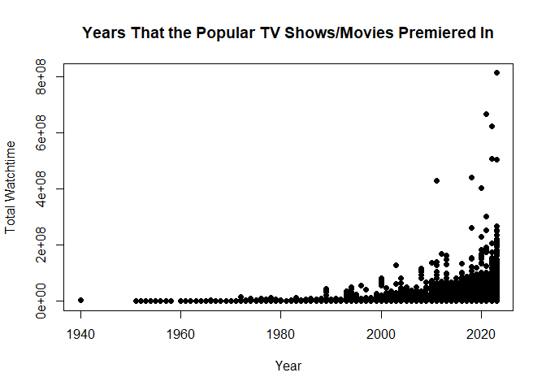

```r
plot(x = data$Premiere, y = data$Watchtime,
     xlab = "Year",
     ylab = "Total Watchtime",
     main = "Years That the Popular TV Shows/Movies Premiered In",
     type = "p",
     lty = 1, lwd = 1,
     pch = 16,
     cex = 1, cex.axis = 1, cex.lab = 1)
```

Based on this plot, it is clear that the years with the least amount of popular tv shows/movies are in the 1940’s and maybe a couple in the 1950’s. Because of this information, it is easier to narrow down exactly which years have the least by counting up all the tv shows/movies that premiered each year in the 1940’s and 1950’s.

```r
#counting how many popular TV Shows/Movies premiered each year in the 1940's
year_1940 <- data %>%
  filter(Premiere == "1940") %>%
  nrow()

year_1941 <- data %>%
  filter(Premiere == "1941") %>%
  nrow()

year_1942 <- data %>%
  filter(Premiere == "1942") %>%
  nrow()

year_1943 <- data %>%
  filter(Premiere == "1943") %>%
  nrow()

year_1944 <- data %>%
  filter(Premiere == "1944") %>%
  nrow()

year_1945 <- data %>%
  filter(Premiere == "1945") %>%
  nrow()

year_1946 <- data %>%
  filter(Premiere == "1946") %>%
  nrow()

year_1947 <- data %>%
  filter(Premiere == "1947") %>%
  nrow()

year_1948 <- data %>%
  filter(Premiere == "1948") %>%
  nrow()

year_1949 <- data %>%
  filter(Premiere == "1949") %>%
  nrow()
```

```r
#counting how many popular TV Shows/Movies premiered each year in the 1950's and 1960
year_1950 <- data %>%
  filter(Premiere == "1950") %>%
  nrow()

year_1951 <- data %>%
  filter(Premiere == "1951") %>%
  nrow()

year_1952 <- data %>%
  filter(Premiere == "1952") %>%
  nrow()

year_1953 <- data %>%
  filter(Premiere == "1953") %>%
  nrow()

year_1954 <- data %>%
  filter(Premiere == "1954") %>%
  nrow()

year_1955 <- data %>%
  filter(Premiere == "1955") %>%
  nrow()

year_1956 <- data %>%
  filter(Premiere == "1956") %>%
  nrow()

year_1957 <- data %>%
  filter(Premiere == "1957") %>%
  nrow()

year_1958 <- data %>%
  filter(Premiere == "1958") %>%
  nrow()

year_1959 <- data %>%
  filter(Premiere == "1959") %>%
  nrow()
```

```r
#making a Dataframe with the amount of movies that premiered each year from 1940-1959
year <- c("1940", "1941", "1942", "1943", "1944", "1945", "1946", "1947", "1948", "1949",
          "1950", "1951", "1952", "1953", "1954", "1955", "1956", "1957", "1958", "1959")
amount_lowest <- c(year_1940, year_1941, year_1942, year_1943, year_1944, year_1945, year_1946, year_1947, year_1948, year_1949,
            year_1950, year_1951, year_1952, year_1953, year_1954, year_1955, year_1956, year_1957, year_1958, year_1959)

#creating Dataframe
df_year_amount_1900s <- data.frame(year, amount_lowest)
df_year_amount_1900s
```

```
##    year amount_lowest
## 1  1940             1
## 2  1941             0
## 3  1942             0
## 4  1943             0
## 5  1944             0
## 6  1945             0
## 7  1946             0
## 8  1947             0
## 9  1948             0
## 10 1949             0
## 11 1950             0
## 12 1951             1
## 13 1952             1
## 14 1953             4
## 15 1954             2
## 16 1955             1
## 17 1956             2
## 18 1957             2
## 19 1958             2
## 20 1959             0
```

Since 0 is the lowest amount, I’m going to look at which rows have 0’s in them.

```r
#filtering out only the years that have 0's in them
amount_0 <- df_year_amount_1900s %>%
  filter(amount_lowest == "0")

amount_0
```

```
##    year amount_lowest
## 1  1941             0
## 2  1942             0
## 3  1943             0
## 4  1944             0
## 5  1945             0
## 6  1946             0
## 7  1947             0
## 8  1948             0
## 9  1949             0
## 10 1950             0
## 11 1959             0
```

There are multiple years that have the least amount of popular releases. The years are 1941, 1942, 1943, 1944, 1945, 1946, 1947, 1948, 1949, 1950, and 1959.

### Which year(s) had the most amount of popular tv shows/movies?

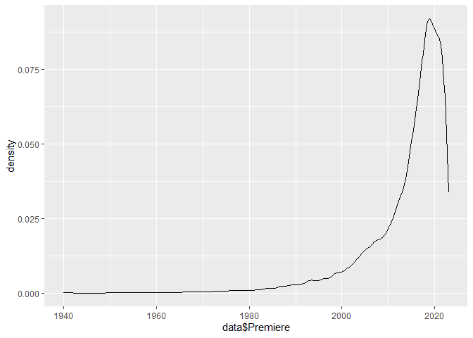

```r
ggplot(data = data, aes(x = data$Premiere)) + geom_density()
```

Based on this plot, it is clear that the year(s) with the most amount of popular tv shows/movies is between 2017 and 2020. Because of this information, it is easier to narrow down exactly which years have the most by counting up all the tv shows/movies that premiered in 2017, 2018, 2019, and 2020.

```r
#counting how many popular TV Shows/Movies premiered each year from 2017-2020
year_2017 <- data %>%
  filter(Premiere == "2017") %>%
  nrow()

year_2018 <- data %>%
  filter(Premiere == "2018") %>%
  nrow()

year_2019 <- data %>%
  filter(Premiere == "2019") %>%
  nrow()

year_2020 <- data %>%
  filter(Premiere == "2020") %>%
  nrow()
```

```r
#making a Dataframe with the amount of movies that premiered each year from 2017-2020
year <- c("2017", "2018", "2019", "2020")
amount_highest <- c(year_2017, year_2018, year_2019, year_2020)

#creating Dataframe
df_year_amount_2000s <- data.frame(year, amount_highest)
df_year_amount_2000s
```

```
##   year amount_highest
## 1 2017           1255
## 2 2018           1626
## 3 2019           1706
## 4 2020           1542
```

Finding the max amount.

```r
max(df_year_amount_2000s$amount_highest)
```

```
## [1] 1706
```

Since 1706 is the largest amount, I’m going to look at which row has 1706.

```r
#filtering out only the row with the biggest amount of popular tv shows/movies which in this case is 1706
amount_1706 <- df_year_amount_2000s %>%
  filter(amount_highest == "1706")

amount_1706
```

```
##   year amount_highest
## 1 2019           1706
```

Based on the results, the year that had the most amount of popular tv shows/movies is 2019.

### Which genre is the most popular and which is the least popular for both tv shows and movies?

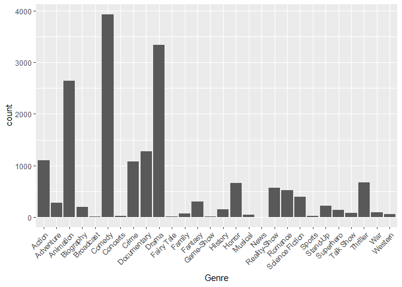

```r
#barplot
ggplot(data = data, aes(x = Genre)) +
  geom_bar() +
  theme(axis.text.x=element_text(angle = 45, hjust=1))
```

Based on this plot, “Comedy” is the most popular genre, and “News” is the least popular genre.

### Which genre is the most popular and which is the least popular specifically for movies?

```r
#filtering out only the movies
most_popular_movies <- data %>%
  filter(Type == "Movie")
```

Making a barplot with just the data on the movies.

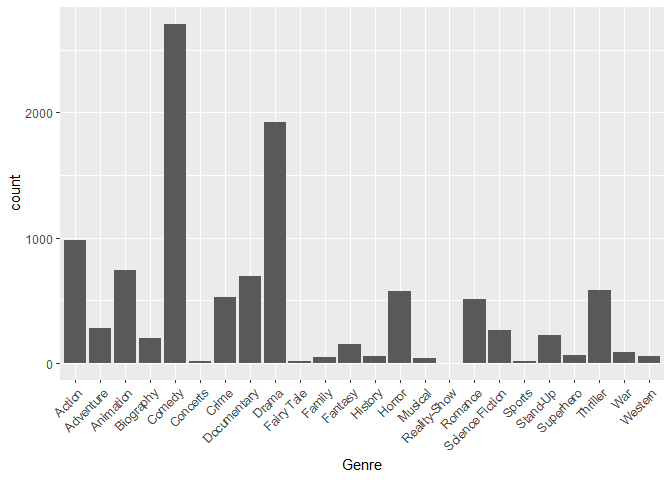

```r
#barplot
ggplot(data = most_popular_movies, aes(x = Genre)) +
  geom_bar() +
  theme(axis.text.x=element_text(angle = 45, hjust=1))
```

In this plot that contains only movies, “Comedy” is still the most popular genre. However, the least popular genre is “Reality Show”. Interestingly, there is no “News” genre at all. It also makes sense that “Reality Show” is the least popular genre just because that genre is usually for tv shows and not movies.

### Which genre is the most popular and which is the least popular specifically for tv shows?

```r
#filtering out only the movies
most_popular_tvshows <- data %>%
  filter(Type == "TV Show")
```

Making a barplot with just the data on the tv shows.

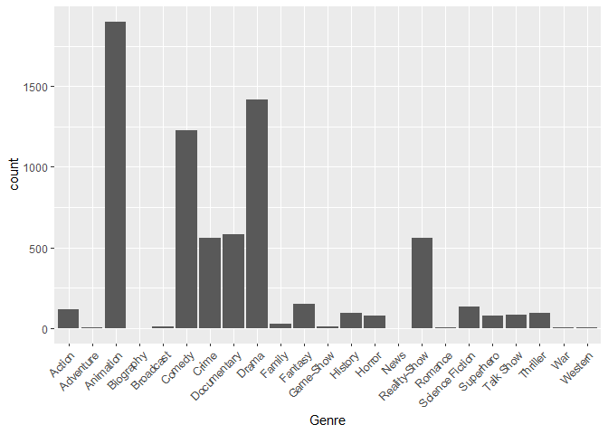

```r
#barplot
ggplot(data = most_popular_tvshows, aes(x = Genre)) +
  geom_bar() +
  theme(axis.text.x=element_text(angle = 45, hjust=1))
```

In this plot that contains only tv shows, “Animation” is the most popular genre. Although, it’s hard to tell what the least popular genre is from this plot. So, I will count how many tv shows have the genres “Adventure”, “Biography”, “News”, “War”, and “Western”. This will give an accurate answer as to which genre(s) is the least popular when it comes to tv shows.

```r
genre_adventure <- most_popular_tvshows %>%
  filter(Genre == "Adventure") %>%
  nrow()

genre_biography <- most_popular_tvshows %>%
  filter(Genre == "Biography") %>%
  nrow()

genre_news <- most_popular_tvshows %>%
  filter(Genre == "News") %>%
  nrow()

genre_war <- most_popular_tvshows %>%
  filter(Genre == "War") %>%
  nrow()

genre_western <- most_popular_tvshows %>%
  filter(Genre == "Western") %>%
  nrow()
```

```r
#making a Dataframe with the amount of movies that have these genres
genre <- c("Adventure", "Biography", "News", "War", "Western")
amount_of_tvshows <- c(genre_adventure, genre_biography, genre_news, genre_war, genre_western)

#creating Dataframe
df_genre_amount_of_tvshows <- data.frame(genre, amount_of_tvshows)
df_genre_amount_of_tvshows
```

```
##       genre amount_of_tvshows
## 1 Adventure                 4
## 2 Biography                 1
## 3      News                 1
## 4       War                 5
## 5   Western                 2
```

Based on these results, the two least popular genres when it comes to tv shows are “Biography” and “News”.